# Exercise 1

## Question 1

### Section 1

```r
fruitflies = read.table(file="data/fruitflies.txt", header=TRUE)
fruitflies = cbind(fruitflies, log(fruitflies[,2]))
names(fruitflies)[4] = "loglongevity"
head(fruitflies,6) # some output deleted
```

```
##   thorax longevity activity loglongevity
## 1   0.64        40 isolated     3.688879
## 2   0.70        37 isolated     3.610918
## 3   0.72        44 isolated     3.784190
## 4   0.72        47 isolated     3.850148
## 5   0.72        47 isolated     3.850148
## 6   0.76        47 isolated     3.850148
```

### Section 2

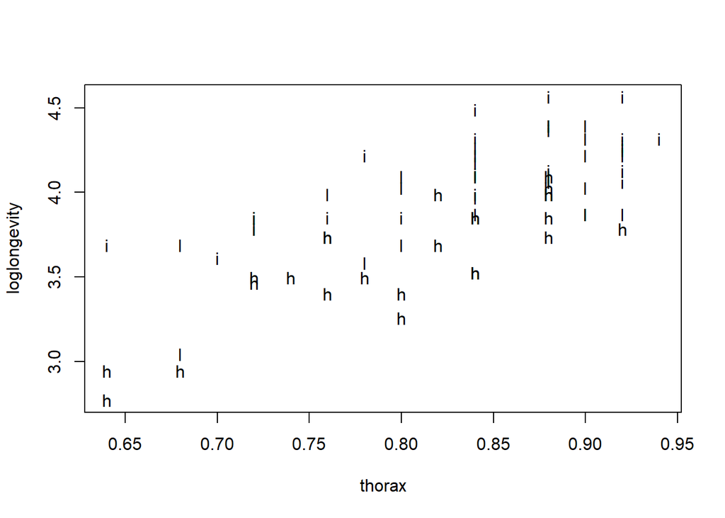

```r
attach(fruitflies)
plot(loglongevity~thorax,pch=as.character(activity))
```

The plot shows a linear correlation between thoractic length (`thorax`) and log longevity. It seems to indicate that flies with the `activity` factor set to `high` live shorter than those with `low`, which in turn score lower than those with `isolated`, assuming equal thoractic length between specimens.

### Section 3

# might need to expand these with more interpretation, perhaps QQ plot checks etc.?

```r
fruitfliesaov = lm(loglongevity~activity, data=fruitflies)
attach(fruitfliesaov)
anova(fruitfliesaov)
```

```
## Analysis of Variance Table
##
## Response: loglongevity
##           Df Sum Sq Mean Sq F value    Pr(>F)
## activity   2 3.6665  1.8333  19.421 1.798e-07 ***
## Residuals 72 6.7966  0.0944
## ---
## Signif. codes:  0 '***' 0.001 '**' 0.01 '*' 0.05 '.' 0.1 ' ' 1
```

According to this analysis, `activity` seems likely to have an effect on `loglongevity`, since the p-value $< 0.05$ (p-value $\approx1.8\times 10^{-7}$). Thus, sexual activity seems to influence longevity.

### Section 4

the analysis shows that sexual activity decreases longevity in fruitflies, since the `activity` factor affects `loglongevity`.

```r
summary(fruitfliesaov)
```

```
##
## Call:
## lm(formula = loglongevity ~ activity, data = fruitflies)
##
## Residuals:
##      Min       1Q   Median       3Q      Max
## -0.95531 -0.13338  0.02552  0.20891  0.49222
##
## Coefficients:
##                  Estimate Std. Error t value Pr(>|t|)
## (Intercept)       3.60212    0.06145  58.621  < 2e-16 ***
## activityisolated  0.51722    0.08690   5.952 8.82e-08 ***
## activitylow       0.39771    0.08690   4.577 1.93e-05 ***
## ---
## Signif. codes:  0 '***' 0.001 '**' 0.01 '*' 0.05 '.' 0.1 ' ' 1
##
## Residual standard error: 0.3072 on 72 degrees of freedom
## Multiple R-squared:  0.3504, Adjusted R-squared:  0.3324
## F-statistic: 19.42 on 2 and 72 DF,  p-value: 1.798e-07
```

# could recheck these means by doing visual to check if they are valid… Not sure if I interpreted estimates right from the slide

the longevity estimates for each level of the factor `activity` are 3.6021243 for fruitflies of level `high`, 3.9998359 for fruitflies of level `low`, and 4.1193489 for fruitflies of level `isolated`. As sexual activity increases, lifespan decreases.

### Section 5

```r
fruitfliesfullaov = lm(loglongevity~thorax+activity, data=fruitflies)
attach(fruitfliesfullaov)
anova(fruitfliesfullaov)
```

```
## Analysis of Variance Table
##
## Response: loglongevity
##           Df Sum Sq Mean Sq F value Pr(>F)
## thorax     1 5.4322  5.4322 132.175 <2e-16 ***
## activity   2 2.1129  1.0565  25.705  4e-09 ***
## Residuals 71 2.9180  0.0411
## ---
## Signif. codes:  0 '***' 0.001 '**' 0.01 '*' 0.05 '.' 0.1 ' ' 1
```

```r
summary(fruitfliesfullaov)$coef
```

```
##                   Estimate Std. Error  t value     Pr(>|t|)
## (Intercept)      1.2189341 0.24864843 4.902239 5.787723e-06
## thorax           2.9789877 0.30665052 9.714602 1.138552e-14
## activityisolated 0.4099810 0.05839296 7.021070 1.074333e-09
## activitylow      0.2857017 0.05848770 4.884817 6.183669e-06
```

### Section 6

Sexual activity decreases longevity, since the estimate is lowest for flies with high sexual activity, and highest for isolated flies.

```r
mean(fruitflies[,1])
```

```
## [1] 0.8245333
```

```r
min(fruitflies[,1])
```

```
## [1] 0.64
```

For an average fly with a thorax length $\approx 0.82,$ the value for parameter $\beta$ given above can be used in a sum to compute all three estimates for loglongevity based on variable $X_{avg}$:

$\mu + \beta * X_{avg} = 1.219 + 2.979 * 0.82 = 3.675$ (high sexual activity)

$\mu + \beta * X_{avg} + \alpha_{1} = 1.219 + 2.979 * 0.82 + 0.286 = 3.961$ (low sexual activity)

$\mu + \beta * X_{avg} + \alpha_{2} = 1.219 + 2.979 * 0.82 + 0.41 = 4.085$ (isolated specimen)

In order to compute the estimates for a fly as small as the smallest fly in the dataset, the term $X$ is substituted with $X_{min}$, the thorax size of the smallest fly in the dataset (0.64).

$\mu + \beta * X_{min} = 1.219 + 2.979 * 0.64 = 3.125$ (high sexual activity)

$\mu + \beta * X_{min} + \alpha_{1} = 1.219 + 2.979 * 0.64 + 0.286 = 3.411$ (low sexual activity)

$\mu + \beta * X_{min} + \alpha_{2} = 1.219 + 2.979 * 0.64 + 0.41 = 3.535$ (isolated specimen)

### Section 7

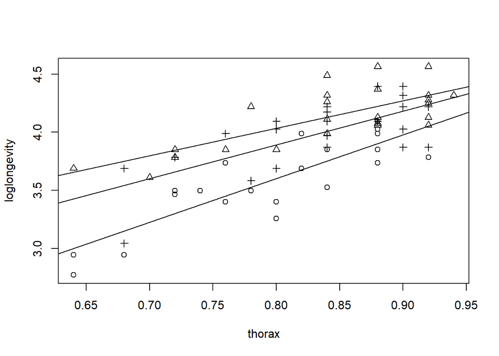

```r
plot(loglongevity~thorax,pch=unclass(activity))
for (i in c("high", "low", "isolated")) abline(lm(loglongevity~thorax,data=fruitflies[fruitflies$activity==i,]))
```